# 資料案例：老忠實

第 18 組

2019-04-01 18:35:09

組員：

- M074050010 簡怡菱 人管所
- m074020026 陳弘翊 資管所
- B054020026 莊子霆 資管系
- B056060016 陳奕瑋 政經系
- B056060041 鄭鈺蓁 政經系
- M074020045 張家銘 資管所

### 💡 學習重點：

【A】從第五周的「[有獎徵答](https://gtonychuo.github.io/2019RPB/unit05/quiz05.html)」我們學到使用`頻率`、`密度`和`機率`來表示`隨機變數`的`分布`  
■ 分布：變數的值所出現的頻率  
■ 連續變數的分布有三種表達方式：次數(頻率)、密度、機率  
■ `連續變數`和`離散變數`的分布的表達方式是不一樣的  
【B】從這一份練習，我們學到：  
■ 平均值、標準差等`統計量`可以表達隨機變數的概況，但它們無法完整表示隨機變數的分布  
■ 透過`圖形`或`數學函數`，我們才能清楚地表示和運算(估計、預測)隨機變數的分布  
■ `模型`：將現實抽象化(Abstract of Reality)，使其好懂(好溝通)或好計算  
■ 圖形和數學函數都可以用來表示隨機變數的分布，前者好懂，後者方便運算  
■ `數值標記`、`直方圖`和`平滑密度曲線`都可以寫成`機率密度函數(PDF)`  
■ 數值標記和直方圖的函數形式比較複雜，也容易有量化誤差  
■ 因此平滑密度曲線通常比較適合用來表示連續變數的分布  
■ 機率密度函數(PDF)積分之後就可以得到`累計機率函數(CDF)`，前者好懂，後者好算  
【C】資料、模型、方法、參數：  
■ 透過調整`方法參數`，同一份資料用同一種`方法`可以做出不同的`模型`  
■ 通常模型越複雜，它跟訓練資料之間的誤差就越小  
■ 但是模型太複雜就會失去一般性，反而不能夠準確的估計訓練資料以外的對象  
■ 所以我們需要用方法參數來控制分析方法的複雜度，避免`過度適配`(`over fitting`)  
【D】估計機率的程序：  
■ 選擇分析方法  
■ 藉由調整方法參數盡量找出最適(PDF)模型  
■ 透過積分，從PDF求出CDF  
■ 根據變數的範圍，從CDF求出機率

### 🗿 問題討論：

【A.選擇方法】  
■ 我們為甚麼需要隨機變數？ 什麼時候我們需要用到隨機變數？  
隨機變數的定義是指變數的值無法預先確定僅以一定的可能性(概率)取值的量。它是由於隨機而獲得的非確定值。所以要有隨機變數才能用以預測未來發生事件的可能性  
什麼時候用到?當我們擁有過去的資料，又想預測未來的機率時候，就會用到了  
■ 隨機變數沒有固定的值，那我們要如何做計算呢？  
用程式模擬(R)預估可能的結果  
■ 我們可以用直方圖或數值標記來估計噴發時間落在某一區間的機率嗎？  
可以，

```
renderGauge({
    DEN = density(D, adjust = input$B)
    PDF = approxfun(DEN$x, DEN$y, yleft=0, yright=0)
    PROB = integrate(PDF, input$R[1], input$R[2])$value<br>
    gauge(round(100*PROB), min = 0, max = 100, symbol = '%', gaugeSectors(
      success = c(41, 100), warning = c(21, 40), danger = c(0, 20)) )
    }),
  sliderInput("R", "數值範圍", 1, 6, c(1,1), 0.2, width='400px')
```

■ 直方圖(histogram)也可以當作一種模型嗎？ 數值標記(rug)呢？  
可以，數值標記只需在原本的code後面加上add=T 就能加入數值標記了  
■ 直方圖和平滑模型哪一個比較適合用來表示噴發時間的分布？ 為甚麼？  
直方圖較為適合，因為當平滑模型的bandwidth太大，將因為曲線太平滑而難以觀察。  
■ 用數值標記來預測噴發時間會比用直方圖「準」嗎？ 「準」是什麼意思呢？  
rug是最準的，因為rug是直接在圖的下方，為每一數值標記一筆。  
在這裡，準的意思是指是否能完整的呈現原始資料的所有內容。  
【B.調整參數】調整一下模型參數的滑桿 …  
■ 你覺得最合適的直方圖欄數(`support/binwidth`)是？ 為甚麼？  
A:直方圖欄數=16較適合；如此一來較能減弱離群值的影響  
■ 最合適的平滑模型頻寬(`bandwidth`)呢？  
A:頻寬=0.5較適合  
■ 調高欄寬和頻寬會讓模型變複雜，還是變簡單呢？  
A:調高欄寬變複雜；平寬變簡單  
■ 模型越複雜，它跟實際值之間的誤差是越大、還是越小？  
A:直方圖越複雜誤差越大；平滑模型越複雜誤差越小  
■ 那麼，越複雜的模型就會越準，對嗎？  
A:錯，因為越複雜的圖形可能涵蓋離群值，做出來的預測結果就會受其影響  
【C.建立模型、估計機率】  
請從課堂筆記的程式碼找出來 …  
■ 從變數向量(`D`)求出機率密度曲線(`DEN`)

```
Adjust = 1    # bandwidth adjustment
DEN = density(D, adjust = Adjust)
lines(DEN, col='gold', lwd=3)
```

■ 將機率密度曲線(`DEN`)轉換成機率密度函數(`PDF`)

```
PDF = approxfun(DEN$x, DEN$y, yleft=0, yright=0)
```

■ 對機率密度函數(`PDF`)做積分，算出機率(`PROB`)

```
integrate(PDF, x1, y1)$value
```

這三行程式，然後…

■ 將頻寬調整參數(`adjust`)設為`1`，算出「等待時間」落在80到90之間的機率

```
x1 = 80; x2 = 90
rect(x1,-0.1,x2,1.2,col= rgb(0,1,0,alpha=0.2),border=NA)
(integrate(PDF, x1, x2)$value)
機率為0.2685
```

■ 將頻寬調整參數設為`0.5`，算出等待時間落在80到90之間的機率  
answer:0.2827451

■ 算出來的機率比較高的就是比較好的模型，對嗎？ 為甚麼？  
answer:機率變大只是因為每個區間的範圍改的比較細，會越接近預測  
【D.預測與決策】  
假設有一個賭局，你可以花30元選定一個連續60秒的時段，如果老忠實下一次的噴發時間落在你指定的區間，你就可以贏到100元；請你使用頻寬為`0.5`的平滑密度模型 …  
■ 決定要不要參加這個賭局  
當然要！  
■ 如果你參加的話，你要把噴發時間設定在哪一個區間呢？  
3.9-4.9  
■ 你設在這個區間的話，參加這個賭局的期望值是？  
期望值 = 0.48`*`70 + 0.52`*`(-30) = 18  
假如賭場老闆從零開始把每10秒鐘設為一個區間，每個區間的賭金是五塊錢 …  
■ 你要怎麼押注，才能獲得最高的期望值呢？

```r
# 匯入dplyr套件
library(dplyr)

#取得噴發持續時間
W = faithful$eruptions

# Smooth PDF
Adjust = 0.5    # bandwidth adjustment
DEN = density(W, adjust = Adjust)

# Smooth CDF
PDF = approxfun(DEN$x, DEN$y, yleft=0, yright=0)

#取得每10秒的時間區間
seq_time = seq(1,6,1/6)

# 計算每10秒的發生機率，並計算期望值（沒中(-5 * (1-pro)) ＋ 中((100-5) * pro）
ans = sapply(seq_time, function(x){
  pro = integrate(PDF, x,(x+(1/6)))$value
  -5*(1-pro) + 95*pro
})

# 計算結束時間
end = seq_time+(1/6)

# 整合開始時間與結束時間為一字串 (start ~ end)
seq.time.data = data.frame(start=paste(seq_time,"~",end))

# 放入期望值到data.frame
seq.time.data$exp = ans

# 取出期望值大於0的放到target)time
target_time = seq.time.data[seq.time.data$exp>0,]

# 印出data.frame
target_time
```

```
                                 start    exp
5  1.66666666666667 ~ 1.83333333333333 1.3668
6                 1.83333333333333 ~ 2 3.2258
7                 2 ~ 2.16666666666667 1.9676
18                3.83333333333333 ~ 4 0.8341
19                4 ~ 4.16666666666667 2.6536
20 4.16666666666667 ~ 4.33333333333333 3.9324
21              4.33333333333333 ~ 4.5 4.5766
22              4.5 ~ 4.66666666666667 3.9384
23 4.66666666666667 ~ 4.83333333333333 1.8427
```

■ 你的賭金和期望值各是多少？

```r
# 賭金
pay_value = 5 * nrow(target_time)
pay_value
```

```
[1] 45
```

```r
# 期望值
get_value = sum(target_time$exp)
get_value
```

```
[1] 24.34
```

將獲利的期望值和賭金的比值稱為「期望投資報酬率」 …  
■ 「最大期望投資報酬率」和「最大期望報酬」的投資策略是一樣的嗎？

```r
get_value / pay_value
```

```
[1] 0.5408
```

不一樣，最大投資報酬率有考慮到每個投入的賭金的效益，最大期望報酬只求獲利最大。  
■ 你認為哪一個策略目標比較好呢？ 為什麼？  
最大投資報酬率比較好，因爲還有考慮到本金的問題。

### Faith.R

```r
library(dplyr)
summary(faithful)
```

```
   eruptions       waiting
 Min.   :1.60   Min.   :43.0
 1st Qu.:2.16   1st Qu.:58.0
 Median :4.00   Median :76.0
 Mean   :3.49   Mean   :70.9
 3rd Qu.:4.45   3rd Qu.:82.0
 Max.   :5.10   Max.   :96.0
```

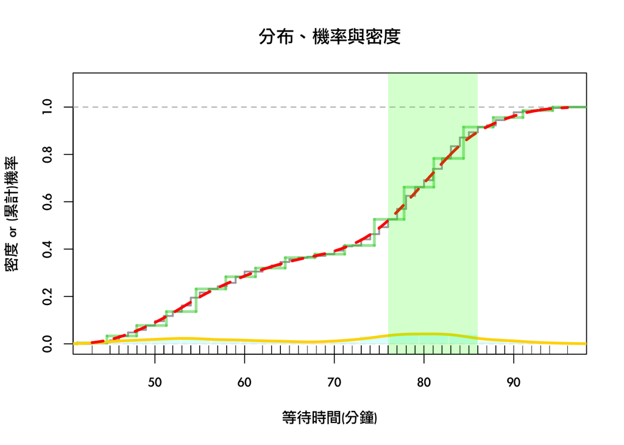

```r
D = faithful$waiting  # copy to a short name

# Frame
plot(0,0,xlim=c(43,96),ylim=c(0,1.1),xlab="等待時間(分鐘)",
     ylab="密度 or (累計)機率", main="分布、機率與密度",family="LiGothicMed")
abline(h=1, col='lightgray', lwd=0.25, lty=2)

# Empirical PDF
rug(D)
# Empirical CDF
plot(ecdf(D), cex=0, verticals=T, lwd=2, col='darkgray', add=T)

# Histogram PDF
Bins = 16                            # no. bins
bx = seq(min(D), max(D), length=Bins+1) # break sequence
hist(D, col="#B3FFFF7F", border="white", ylim=c(0,1.1),
     freq=F, breaks=bx, add=T)
abline(h=0, col='lightgray', lwd=0.25)
# Histogram CDF
adj = (bx[2] - bx[1])/2
steps = stepfun(bx-adj, c(0, sapply(bx, function(b) mean(D <= b))))
plot(steps, cex=0, col='#33CC337F', lwd=3, lty=1, add=T)

# Smooth PDF
Adjust = 0.5    # bandwidth adjustment
DEN = density(D, adjust = Adjust)
lines(DEN, col='gold', lwd=3)
# Smooth CDF
PDF = approxfun(DEN$x, DEN$y, yleft=0, yright=0)
x = seq(43,96,0.1)
y = sapply(x, function(i) integrate(PDF, -Inf, i)$value)
lines(x, y, col='red', lwd=3, lty=2)

# Mark Range
x1 = 76; x2 = 86
rect(x1,-0.1,x2,1.2,col= rgb(0,1,0,alpha=0.2),border=NA)
```

```r
# x = seq(x1, x2, length=100)
# polygon(c(x, x2, x1),  c(PDF(x), 0, 0), col="#FF99003F", border=NA)
# Calculate Probability
(integrate(PDF, x1, x2)$value)
```

```
[1] 0.3739
```